# R Notebook

# Part I General Strategies

## 3 Data Pre-Processing

### Computing

There were fields that identified each cell (called Cell) and a factor vector that indicated which cells were well segmented (Class). The variable Case indicated which cells were originally used for the training and test sets. The analysis in this chapter focused on the training set samples, so the data are filtered for these cells:

```r
apropos("matrix")
RSiteSearch("confusion", restrict = "functions")

library(AppliedPredictiveModeling)
library(data.table)

data(segmentationOriginal)
segmentationOriginal
str(segmentationOriginal)
sapply(segmentationOriginal, class)
segData <- as.data.table(segmentationOriginal)
# filter on training data
segData <- segData[Case == "Train"]
CellID <- segData$Cell
class <- segData$Class
case <- segData$Case
# Now remove the saved columns
segData <- segData[, -(1:3)]
# remove 'Status' columns
statusColNum <- grep("Status", names(segData))
statusColNum
segData <- segData[, -..statusColNum]
```

#### Transformations

```r
# As previously discussed, some features exhibited significantly skewness. The skewness function in the e1071 package calculates the sample skewness statistic for each predictor:

library(e1071)

# For one predictor:
skewness(segData$AngleCh1)

# Since all the predictors are numeric columns, the apply function can be used to compute the skewness across columns.

skewValues <- apply(segData, 2, skewness)
head(skewValues)
hist(segData$EqEllipseOblateVolCh1)

# Using these values as a guide, the variables can be prioritized for visualizing the distribution.  The basic R function hist or the histogram function in the lattice can be used to assess the shape of the distribution. To determine which type of transformation should be used, the MASS package contains the boxcox function. Although this function estimates λ, it does not create the transformed variable(s).

# A caret function, BoxCoxTrans, can find the appropriate transformation and apply them to the new data:

library(caret)
Ch1AreaTrans <- caret::BoxCoxTrans(segData$AreaCh1)
Ch1AreaTrans

# The original data
head(segData$AreaCh1)

# After transformation
predict(Ch1AreaTrans, head(segData$AreaCh1))
(819^(-.9) - 1)/(-.9)
```

Another caret function, **preProcess**, applies this transformation to a set of predictors. This function is discussed below.

The base R function **prcomp** can be used for PCA. In the code below, the data are centered and scaled prior to **PCA**:

```r
pcaObject <- prcomp(segData,
                    center = TRUE,
                    scale. = TRUE)

# Calculate the cumulative percentage of variance which each component accounts for.

percentVariance <- pcaObject$sd^2/sum(pcaObject$sd^2)*100
percentVariance[1:3]

# The transformed values are stored in pcaObject as a sub-object called x:

head(pcaObject$x[, 1:5])
```

The another sub-object called **rotation** stores the **variable loadings**, where rows correspond to predictor variables and columns are associated with the components:

```r
head(pcaObject$rotation[, 1:3])
```

The caret package class spatialSign contains functionality for the **spatial sign transformation**. Although we will not apply this technique to these data, the basic syntax would be spatialSign(segData).

Also, these data do not have **missing values** for imputation. To impute missing values, the impute package has a function, **impute.knn**, that uses K-nearest neighbors to estimate the missing data. The previously mentioned preProcess function applies imputation methods based on K-nearest neighbors or bagged trees.

To administer a series of transformations to multiple data sets, the **caret class preProcess** has the ability to

- transform,
- center,
- scale, or
- impute values, as well as
- apply the spatial sign transformation and
- feature extraction.

The function calculates the required quantities for the transformation. After calling the preProcess function, the predict method applies the results to a set of data. For example, to Box–Cox transform, center, and scale the data, then execute PCA for signal extraction, the syntax would be:

```r
trans <-
        caret::preProcess(segData,
                          method = c("BoxCox", "center", "scale", "pca"))
trans
trans$dim
trans$rotation

# Apply the transformations:
transformed <- predict(trans, segData)

# These values are different than the previous PCA components since they were transformed prior to PCA
head(transformed[, 1:5])
```

The **order** in which the possible transformation are applied is:

- transformation,
- centering,
- scaling,
- imputation,
- feature extraction, and then
- spatial sign.

Many of the modeling functions have options to center and scale prior to modeling. For example, when using the train function (discussed in later chapters), there is an option to use preProcess prior to modeling within the resampling iterations.

#### Filtering

To filter for **near-zero variance predictors**, the caret package function **nearZeroVar** will return the column numbers of any predictors that fulfill the conditions outlined in Sect. 3.5. For the cell segmentation data, there are no problematic predictors:

```r
nearZeroVar(segData)

# When predictors should be removed, a vector of integers is returned that indicates which columns should be removed.

# Similarly, to filter on between-predictor correlations, the cor function can calculate the correlations between predictor variables:

correlations <- cor(segData)
dim(correlations)
correlations[1:4, 1:4]
str(correlations)
```

##### corrplot()

To visually examine the correlation structure of the data, the corrplot pack- age contains an excellent function of the same name. The function has many options including one that will reorder the variables in a way that reveals clusters of highly correlated predictors.

```r
library(corrplot)
corrplot(correlations, order = "hclust")
```

```r
highCorr <- findCorrelation(correlations, cutoff = .75)
length(highCorr)
head(highCorr)
filteredSegData <- segData[, -highCorr]
```

#### Creating Dummy Variables

Several methods exist for creating dummy variables based on a particular model. Section 4.9 discusses different methods for specifying how the predictors enter into the model. One approach, the formula method, allows great flexibility to create the model function. Using formulas in model functions parameterizes the predictors such that not all categories have dummy variables. This approach will be shown in greater detail for linear regression. As previously mentioned, there are occasions when a complete set of dummy variables is useful. For example, the splits in a tree-based model are more interpretable when the dummy variables encode all the information for that predictor. We recommend using the full set if dummy variables when working with tree-based models.

Example dummyVars:

```r
when <- data.frame(time = c("afternoon", "night", "afternoon",
                            "morning", "morning", "morning",
                            "morning", "afternoon", "afternoon"),
                   day = c("Mon", "Mon", "Mon",
                           "Wed", "Wed", "Fri",
                           "Sat", "Sat", "Fri"),
                           stringsAsFactors = TRUE)

when

levels(when$time) <- list(morning="morning",
                          afternoon="afternoon",
                          night="night")
when

levels(when$day) <- list(Mon="Mon", Tue="Tue", Wed="Wed", Thu="Thu",
                         Fri="Fri", Sat="Sat", Sun="Sun")

## Default behavior:
model.matrix(~day, when)

mainEffects <- dummyVars(~ day + time, data = when)
mainEffects
predict(mainEffects, when[1:3,])

when2 <- when
when2[1, 1] <- NA
when2
when2[1:3,]
predict(mainEffects, when2[1:3,])
predict(mainEffects, when2[1:3,], na.action = na.omit)


interactionModel <- dummyVars(~ day + time + day:time,
                              data = when,
                              sep = ".")

predict(interactionModel, when[1:3,])

noNames <- dummyVars(~ day + time + day:time,
                     data = when,
                     levelsOnly = TRUE)
predict(noNames, when)

head(class2ind(iris$Species))

two_levels <- factor(rep(letters[1:2], each = 5))
class2ind(two_levels)
class2ind(two_levels, drop2nd = TRUE)
```

### Exercises

#### 3.1.

The UC Irvine Machine Learning Repository contains a data set related to glass identification. The data consist of 214 glass samples labeled as one of seven class categories. There are nine predictors, including the refractive index and percentages of eight elements: Na, Mg, Al, Si, K, Ca, Ba, and Fe. The data can be accessed via:

1. Using visualizations, **explore** the predictor variables to understand their distributions as well as the relationships between predictors.
2. Do there appear to be any **outliers** in the data? Are any predictors **skewed**?
3. Are there any relevant transformations of one or more predictors that might improve the classification model?

```r
library(mlbench)
data(Glass)
str(Glass)
head(Glass)
```

##### Explore

```r
library(reshape2)
meltedGlass <- melt(Glass, id.vars = "Type")
head(meltedGlass)

# Now, we can use the lattice function densityplot to look at each predictor:
library(lattice)

lattice::densityplot(~value|variable,
            data = meltedGlass,
            ## Adjust each axis so that the measurement scale is
            ## different for each panel
            scales = list(x = list(relation = "free"),
                          y = list(relation = "free")),
            ## 'adjust' smooths the curve out
            adjust = 1.25,
            ## change the symbol on the rug for each data point
            pch = "|",
            xlab = "Predictor")
```

A scatterplot matrix can also be helpful to visualize a data set of this size.

```r
?pairs
pairs(Glass)
```

```r
library(GGally)
?ggpairs
ggpairs(Glass)
```

1. The **measurements** of some glass types, specifically Fe, Ba, K and Mg, are **zero**. This creates a “mixture distribution” of points; one distribution consists of glass types containing the element in question whereas the other does not. This finding implies that the samples in these distributions may not behave in the same manner.
2. Most predictors are uncorrelated with the exception of pairs Ca/RI and maybe RI/Si.
3. Many of the pair–wise combinations have very **non–standard distributions** (i.e. **heavy tails** or mixtures of distributions).
4. It is difficult to tell if the extreme point in the K data is an **outlier** or just a artifact of a skewed distribution that has not been sampled enough. In either case, this should be accounted for through the modeling, preferably by using models that are resistant to outliers.

Another nice visualization of correlations:

```r
library(corrplot)
Glass_cor <- cor(Glass[, 1:9])
?corrplot
corrplot(Glass_cor, order = "hclust")
corrplot(Glass_cor, method = c("number"), order = "hclust")
```

##### Skewness & Outliers

Would **transformations** help these data?

Based on our findings above, we need to investigate transformations of individual predictors that will **resolve skewness and/or outliers** (e.g. the spatial sign transformation).

For skewness, first note that several predictors have **values of zero**. This excludes transformations such as the log transformation or the Box–Cox family of transformations. When we are faced with predictors containing zero values, the Yeo–Johnson family of transformations can be helpful (Yeo & Johnson 2000). This family of transformations is very similar to the Box–Cox transformation, but can handle zero or negative predictor values. The transformation can be estimated using caret’s preProcess function:

```r
library(caret)
yjTrans <- caret::preProcess(Glass[, -10], method = "YeoJohnson")
yjTrans
yjData <- predict(yjTrans, newdata = Glass[, -10])
yjData
melted <- melt(yjData)
melted
```

Next, we will apply the **spatial sign** transformation to attempt to **mitigate outliers**. For this data, we first center and scale the data, then apply the transformation:

```r
centerScale <- caret::preProcess(Glass[, -10], method = c("center", "scale"))
centerScale
csData <- predict(centerScale, newdata = Glass[, -10])
csData
ssData <- caret::spatialSign(csData)
ssData

lattice::splom(~ssData, pch = 16, col = rgb(.2, .2, .2, .4), cex = .7)
```

Note that attempts to pre–process data to resolve predictor distribution problems are not always successful. Our best efforts in pre–processing may not yield highly desirable transformed values. Under these kinds of circumstances, we will need to use models that are not unduly affected by skewed distributions (e.g. tree–based methods).

#### 3.2. Frequency distributions & missing values

The soybean data can also be found at the UC Irvine Machine Learning Repository. Data were collected to predict disease in 683 soybeans. The 35 predictors are mostly categorical and include information on the environmental conditions (e.g., temperature, precipitation) and plant conditions (e.g., left spots, mold growth). The outcome labels consist of 19 distinct classes.

The data can be loaded via:

```r
library(mlbench)
data(Soybean)
?Soybean
Soybean
```

|  | Class | date | plant.stand | precip | temp | hail | crop.hist | area.dam | sever | seed.tmt | germ | plant.growth | leaves | leaf.halo | leaf.marg | leaf.size | leaf.shread | leaf.malf | leaf.mild | stem | lodging | stem.cankers | canker.lesion | fruiting.bodies | ext.decay | mycelium | int.discolor | sclerotia | fruit.pods | … |
| --- | --- | --- | --- | --- | --- | --- | --- | --- | --- | --- | --- | --- | --- | --- | --- | --- | --- | --- | --- | --- | --- | --- | --- | --- | --- | --- | --- | --- | --- | --- |
| 1 | diaporthe-stem-canker | 6 | 0 | 2 | 1 | 0 | 1 | 1 | 1 | 0 | 0 | 1 | 1 | 0 | 2 | 2 | 0 | 0 | 0 | 1 | 1 | 3 | 1 | 1 | 1 | 0 | 0 | 0 | 0 | … |
| 2 | diaporthe-stem-canker | 4 | 0 | 2 | 1 | 0 | 2 | 0 | 2 | 1 | 1 | 1 | 1 | 0 | 2 | 2 | 0 | 0 | 0 | 1 | 0 | 3 | 1 | 1 | 1 | 0 | 0 | 0 | 0 | … |
| 3 | diaporthe-stem-canker | 3 | 0 | 2 | 1 | 0 | 1 | 0 | 2 | 1 | 2 | 1 | 1 | 0 | 2 | 2 | 0 | 0 | 0 | 1 | 0 | 3 | 0 | 1 | 1 | 0 | 0 | 0 | 0 | … |
| 4 | diaporthe-stem-canker | 3 | 0 | 2 | 1 | 0 | 1 | 0 | 2 | 0 | 1 | 1 | 1 | 0 | 2 | 2 | 0 | 0 | 0 | 1 | 0 | 3 | 0 | 1 | 1 | 0 | 0 | 0 | 0 | … |
| 5 | diaporthe-stem-canker | 6 | 0 | 2 | 1 | 0 | 2 | 0 | 1 | 0 | 2 | 1 | 1 | 0 | 2 | 2 | 0 | 0 | 0 | 1 | 0 | 3 | 1 | 1 | 1 | 0 | 0 | 0 | 0 | … |
| 6 | diaporthe-stem-canker | 5 | 0 | 2 | 1 | 0 | 3 | 0 | 1 | 0 | 1 | 1 | 1 | 0 | 2 | 2 | 0 | 0 | 0 | 1 | 0 | 3 | 0 | 1 | 1 | 0 | 0 | 0 | 0 | … |
| 7 | diaporthe-stem-canker | 5 | 0 | 2 | 1 | 0 | 2 | 0 | 1 | 1 | 0 | 1 | 1 | 0 | 2 | 2 | 0 | 0 | 0 | 1 | 1 | 3 | 1 | 1 | 1 | 0 | 0 | 0 | 0 | … |
| 8 | diaporthe-stem-canker | 4 | 0 | 2 | 1 | 1 | 1 | 0 | 1 | 0 | 2 | 1 | 1 | 0 | 2 | 2 | 0 | 0 | 0 | 1 | 0 | 3 | 1 | 1 | 1 | 0 | 0 | 0 | 0 | … |
| 9 | diaporthe-stem-canker | 6 | 0 | 2 | 1 | 0 | 3 | 0 | 1 | 1 | 1 | 1 | 1 | 0 | 2 | 2 | 0 | 0 | 0 | 1 | 0 | 3 | 1 | 1 | 1 | 0 | 0 | 0 | 0 | … |
| 10 | diaporthe-stem-canker | 4 | 0 | 2 | 1 | 0 | 2 | 0 | 2 | 0 | 2 | 1 | 1 | 0 | 2 | 2 | 0 | 0 | 0 | 1 | 0 | 3 | 1 | 1 | 1 | 0 | 0 | 0 | 0 | … |

[output cut: 673 more lines]

```r
table(Soybean$Class)
```

```
               2-4-d-injury         alternarialeaf-spot                 anthracnose
                         16                          91                          44
           bacterial-blight           bacterial-pustule                  brown-spot
                         20                          20                          92
             brown-stem-rot                charcoal-rot               cyst-nematode
                         44                          20                          14
diaporthe-pod-&-stem-blight       diaporthe-stem-canker                downy-mildew
                         15                          20                          20
         frog-eye-leaf-spot            herbicide-injury      phyllosticta-leaf-spot
                         91                           8                          20
           phytophthora-rot              powdery-mildew           purple-seed-stain
                         88                          20                          20
       rhizoctonia-root-rot
                         20
```

```r
str(Soybean)
```

```
'data.frame':   683 obs. of  36 variables:
 $ Class          : Factor w/ 19 levels "2-4-d-injury",..: 11 11 11 11 11 11 11 11 11 11 ...
 $ date           : Factor w/ 7 levels "0","1","2","3",..: 7 5 4 4 7 6 6 5 7 5 ...
 $ plant.stand    : Ord.factor w/ 2 levels "0"<"1": 1 1 1 1 1 1 1 1 1 1 ...
 $ precip         : Ord.factor w/ 3 levels "0"<"1"<"2": 3 3 3 3 3 3 3 3 3 3 ...
 $ temp           : Ord.factor w/ 3 levels "0"<"1"<"2": 2 2 2 2 2 2 2 2 2 2 ...
 $ hail           : Factor w/ 2 levels "0","1": 1 1 1 1 1 1 1 2 1 1 ...
 $ crop.hist      : Factor w/ 4 levels "0","1","2","3": 2 3 2 2 3 4 3 2 4 3 ...
 $ area.dam       : Factor w/ 4 levels "0","1","2","3": 2 1 1 1 1 1 1 1 1 1 ...
 $ sever          : Factor w/ 3 levels "0","1","2": 2 3 3 3 2 2 2 2 2 3 ...
 $ seed.tmt       : Factor w/ 3 levels "0","1","2": 1 2 2 1 1 1 2 1 2 1 ...
 $ germ           : Ord.factor w/ 3 levels "0"<"1"<"2": 1 2 3 2 3 2 1 3 2 3 ...
 $ plant.growth   : Factor w/ 2 levels "0","1": 2 2 2 2 2 2 2 2 2 2 ...
 $ leaves         : Factor w/ 2 levels "0","1": 2 2 2 2 2 2 2 2 2 2 ...
 $ leaf.halo      : Factor w/ 3 levels "0","1","2": 1 1 1 1 1 1 1 1 1 1 ...
```

[output cut: 22 more lines]

See ?Soybean for details

1. Investigate the **frequency distributions for the categorical predictors**. Are any of the distributions degenerate in the ways discussed earlier in this chapter?
2. Roughly 18 % of the data are **missing**. Are there particular predictors that are more likely to be missing? Is the pattern of missing data related to the classes?
3. Develop a **strategy for handling missing data**, either by eliminating predictors or imputation.

##### table()

```r
Soybean2 <- Soybean
table(Soybean2$temp, useNA = "always")
```

```
   0    1    2 <NA>
  80  374  199   30
```

```r
# alternative method
library(car)
Soybean2$temp <- car::recode(Soybean2$temp,
                             "0 = 'low'; 1 = 'norm'; 2 = 'high'; NA = 'missing'",
                             levels = c("low", "norm", "high", "missing"))

# NA is not changed to 'missing' with this (base R) method
# levels(Soybean2$temp) <- c("low", "norm", "high")

table(Soybean2$temp)
```

```
    low    norm    high missing
     80     374     199      30
```

For this part of the solution to this problem, we will look at the relationship between the months, temperature and precipitation. To explore these relationships, we need to recode months and precipitation.

```r
table(Soybean2$date, useNA = "always")
```

```
   0    1    2    3    4    5    6 <NA>
  26   75   93  118  131  149   90    1
```

```r
Soybean2$date <-
  car::recode(Soybean2$date,
              "0 ='apr';1='may';2='june';3='july';4='aug';5='sept';6='oct';NA = 'missing'",
              levels = c("apr", "may", "june", "july", "aug", "sept", "missing"))
table(Soybean2$date)
```

```
    apr     may    june    july     aug    sept missing
     26      75      93     118     131     149       1
```

```r
table(Soybean2$precip, useNA = "always")
```

```
   0    1    2 <NA>
  74  112  459   38
```

```r
Soybean2$precip <- car::recode(Soybean2$precip,
                               "0 = 'low'; 1 = 'norm'; 2 = 'high'; NA = 'missing'",
                               levels = c("low", "norm", "high", "missing"))
table(Soybean2$precip)
```

```
    low    norm    high missing
     74     112     459      38
```

To start, let’s look at the date predictor. Are the months represented equally? From the table above, we can see that June through September have the most data and that there is a single missing value. For precipitation (ironically) most of the data are above average. In addition, the temperature and precipitation columns have missing value rates of about 5%.

##### vcd::mosaic()

Like the previous problems, we should examine the pair-wise or joint distributions of these predic- tors. Joint distributions of factor predictors are often displayed in a contingency table. There are also several ways that these distributions can be displayed in a graph. The mosaic function in the vcd package (Meyer, Zeileis & Hornik 2006) and the barchart function in the lattice package are two options. What does the joint distribution of temperature and month look like? First, we will use a mosaic plot:

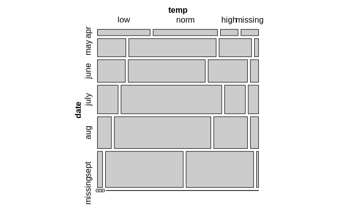

```r
library(vcd)
## mosaic() can table a table or a formula:
vcd::mosaic(~date + temp, data = Soybean2)
```

```r
table(Soybean2$date, Soybean2$temp)
```

```
          low norm high missing
  apr       9   11    3       3
  may      14   43   16       2
  june     17   47   24       5
  july     16   78   16       8
  aug      12   83   29       7
  sept      5   76   66       2
  missing   0    0    0       1
```

##### lattice::barchart

Alternatively, a bar chart can also be used:

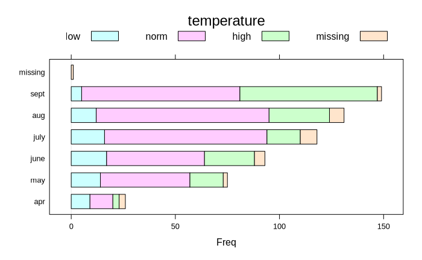

```r
lattice::barchart(table(Soybean2$date, Soybean2$temp),
                  auto.key = list(columns = 4, title = "temperature"))
```

The results are shown in Figure 5. Note that in the bar chart, the bars are not cumulative (i.e. missing values are not the most frequent). Here we see which months are the most frequent. Additionally, we see that average temperatures are the most frequent category within each month, although high temperatures are also very likely in September. Missing values are most likely in July. One useful option to barchart is stack to create stacked bars. To investigate higher–order relationships, predictors can be added to the table or formula to create more complex visualizations (e.g. panels in the lattice plots, etc). What does the distribution look like per response class for the missing data? If we look at the frequency of any missing predictor value per class, the results show that some classes are more problematic than others:

```r
table(Soybean$Class, complete.cases(Soybean))
```

```
                              FALSE TRUE
  2-4-d-injury                   16    0
  alternarialeaf-spot             0   91
  anthracnose                     0   44
  bacterial-blight                0   20
  bacterial-pustule               0   20
  brown-spot                      0   92
  brown-stem-rot                  0   44
  charcoal-rot                    0   20
  cyst-nematode                  14    0
  diaporthe-pod-&-stem-blight    15    0
  diaporthe-stem-canker           0   20
  downy-mildew                    0   20
  frog-eye-leaf-spot              0   91
  herbicide-injury                8    0
  phyllosticta-leaf-spot          0   20
  phytophthora-rot               68   20
  powdery-mildew                  0   20
  purple-seed-stain               0   20
  rhizoctonia-root-rot            0   20
```

```r
head(hasMissing)
```

```
[1] "date"        "plant.stand" "precip"      "temp"        "hail"        "crop.hist"
```

There are several classes where all of the samples have at least one missing predictor value. Are these concentrated in a single predictor that we could remove? We can get the percentage of missing values for each predictor by class using the following syntax:

```r
## now print:
t(byPredByClass)
```

```
                2-4-d-injury cyst-nematode diaporthe-pod-&-stem-blight herbicide-injury phytophthora-rot
date                  0.0625             0                         0.0                0        0.0000000
plant.stand           1.0000             1                         0.4                0        0.0000000
precip                1.0000             1                         0.0                1        0.0000000
temp                  1.0000             1                         0.0                0        0.0000000
hail                  1.0000             1                         1.0                1        0.7727273
crop.hist             1.0000             0                         0.0                0        0.0000000
area.dam              0.0625             0                         0.0                0        0.0000000
sever                 1.0000             1                         1.0                1        0.7727273
seed.tmt              1.0000             1                         1.0                1        0.7727273
germ                  1.0000             1                         0.4                1        0.7727273
plant.growth          1.0000             0                         0.0                0        0.0000000
leaf.halo             0.0000             1                         1.0                0        0.6250000
leaf.marg             0.0000             1                         1.0                0        0.6250000
leaf.size             0.0000             1                         1.0                0        0.6250000
leaf.shread           1.0000             1                         1.0                0        0.6250000
leaf.malf             0.0000             1                         1.0                0        0.6250000
leaf.mild             1.0000             1                         1.0                1        0.6250000
stem                  1.0000             0                         0.0                0        0.0000000
lodging               1.0000             1                         1.0                1        0.7727273
stem.cankers          1.0000             1                         0.0                1        0.0000000
canker.lesion         1.0000             1                         0.0                1        0.0000000
fruiting.bodies       1.0000             1                         0.0                1        0.7727273
ext.decay             1.0000             1                         0.0                1        0.0000000
mycelium              1.0000             1                         0.0                1        0.0000000
int.discolor          1.0000             1                         0.0                1        0.0000000
sclerotia             1.0000             1                         0.0                1        0.0000000
fruit.pods            1.0000             0                         0.0                0        0.7727273
fruit.spots           1.0000             1                         0.0                1        0.7727273
seed                  1.0000             0                         0.0                1        0.7727273
mold.growth           1.0000             0                         0.0                1        0.7727273
seed.discolor         1.0000             1                         0.0                1        0.7727273
seed.size             1.0000             0                         0.0                1        0.7727273
shriveling            1.0000             1                         0.0                1        0.7727273
roots                 1.0000             0                         1.0                0        0.0000000
```

From this output, we see that there are many predictors completely missing for the 2-4-d-injury, cyst-nematode and herbicide-injury classes. The phytophthora-rot class has a high rate of missing data across many predictors and the diaporthe-pod-&-stem-blight has a more moderate pattern of missing data.

One approach to handling missing data is to use an imputation technique. However, it is unlikely that imputation will help since almost 100% of the predictor values will need to be imputed in a few cases. We could encode the missing as another level or eliminate the classes associated with the high rate of missing values from the data altogether.

##### caret::dummyVars

How would the frequencies of the predictor values affect the modeling process? If we are using a model that is sensitive to sparsity then the low rate of some of the factor levels might be an issue. We can convert the factors to a set of **dummy variables** and see how good or bad the sparsity is.

```r
head(dummies[1:4,1:14])
```

```
  date.0 date.1 date.2 date.3 date.4 date.5 date.6 plant.stand.0 plant.stand.1 precip.0 precip.1 precip.2 temp.0 temp.1
1      0      0      0      0      0      0      1             1             0        0        0        1      0      1
2      0      0      0      0      1      0      0             1             0        0        0        1      0      1
3      0      0      0      1      0      0      0             1             0        0        0        1      0      1
4      0      0      0      1      0      0      0             1             0        0        0        1      0      1
```

… then nearZeroVar to figure out which should be removed.

```r
predDistInfo <- caret::nearZeroVar(dummies, saveMetrics = TRUE)
head(predDistInfo)
```

The number and percentage of predictors to remove:

```r
sum(predDistInfo$nzv)
```

```
[1] 16
```

```r
mean(predDistInfo$nzv)
```

```
[1] 0.1616162
```

So if we wanted to remove sparse and unbalanced predictors, 16.2% of the dummy variables would be eliminated. One way around this is to use models that are not sensitive to this characteristic, such as tree– or rule–based models, or na¨ıve Bayes.

#### 3.3.

Chapter 5 introduces Quantitative Structure-Activity Relationship (QSAR) modeling where the characteristics of a chemical compound are used to predict other chemical properties. The caret package contains a QSAR data set from Mente and Lombardo (2005). Here, the ability of a chemical to permeate the blood-brain barrier was experimentally determined for 208 compounds. 134 descriptors were measured for each compound.

1. Start R and use these commands to load the data:

|  | tpsa | nbasic | negative | vsa_hyd | a_aro | weight | peoe_vsa.0 | peoe_vsa.1 | peoe_vsa.2 | peoe_vsa.3 | peoe_vsa.4 | peoe_vsa.5 | peoe_vsa.6 | peoe_vsa.0.1 | peoe_vsa.1.1 | peoe_vsa.2.1 | peoe_vsa.3.1 | peoe_vsa.4.1 | peoe_vsa.5.1 | peoe_vsa.6.1 | a_acc | a_acid | a_base | vsa_acc | vsa_acid | vsa_base | vsa_don | vsa_other | vsa_pol | … |
| --- | --- | --- | --- | --- | --- | --- | --- | --- | --- | --- | --- | --- | --- | --- | --- | --- | --- | --- | --- | --- | --- | --- | --- | --- | --- | --- | --- | --- | --- | --- |
| 1 | 12.03 | 1 | 0 | 167.06700 | 0 | 156.293 | 76.94749 | 43.44619 | 0.00000 | 0.000000 | 0.00000 | 0 | 17.238030 | 18.74768 | 43.50657 | 0 | 0 | 0.000000 | 0.000000 | 0.000000 | 0 | 0 | 1 | 0.000000 | 0 | 5.682576 | 5.682576 | 0.00000 | 0.00000 | … |
| 2 | 49.33 | 0 | 0 | 92.64243 | 6 | 151.165 | 38.24339 | 25.52006 | 0.00000 | 8.619013 | 23.27370 | 0 | 0.000000 | 49.01962 | 0.00000 | 0 | 0 | 0.000000 | 13.566920 | 7.904431 | 2 | 0 | 0 | 13.566920 | 0 | 0.000000 | 5.682576 | 28.10760 | 13.56692 | … |
| 3 | 50.53 | 1 | 0 | 295.16700 | 15 | 366.485 | 58.05473 | 124.74020 | 21.65084 | 8.619013 | 17.44054 | 0 | 8.619013 | 83.82487 | 49.01962 | 0 | 0 | 5.682576 | 2.503756 | 2.640647 | 2 | 0 | 1 | 8.186332 | 0 | 0.000000 | 5.682576 | 43.56089 | 0.00000 | … |
| 4 | 37.39 | 0 | 0 | 319.11220 | 15 | 382.552 | 62.23933 | 124.74020 | 13.19232 | 21.785640 | 0.00000 | 0 | 8.619013 | 83.82487 | 68.78024 | 0 | 0 | 5.682576 | 0.000000 | 2.640647 | 2 | 0 | 1 | 8.186332 | 0 | 0.000000 | 5.682576 | 28.32470 | 0.00000 | … |
| 5 | 37.39 | 1 | 0 | 299.65800 | 12 | 326.464 | 74.80064 | 118.04060 | 33.00190 | 0.000000 | 0.00000 | 0 | 8.619013 | 83.82487 | 36.76471 | 0 | 0 | 5.682576 | 0.136891 | 2.503756 | 2 | 0 | 1 | 8.186332 | 0 | 0.000000 | 5.682576 | 19.64908 | 0.00000 | … |
| 6 | 37.39 | 1 | 0 | 289.77770 | 11 | 332.492 | 74.80064 | 109.50990 | 13.19232 | 21.785640 | 0.00000 | 0 | 8.619013 | 73.54603 | 44.27042 | 0 | 0 | 5.682576 | 0.000000 | 2.640647 | 2 | 0 | 1 | 8.186332 | 0 | 0.000000 | 5.682576 | 21.62514 | 0.00000 | … |

The numeric outcome is contained in the vector logBBB while the predictors are in the data frame bbbDescr.

2. Do any of the individual predictors have **degenerate distributions**?
3. Generally speaking, are there strong relationships between the predictor data? If so, how could **correlations** in the predictor set be reduced? Does this have a dramatic effect on the number of predictors available for modeling?

Solutions For these data, the first assessment looks for **sparse and unbalanced predictors**. The caret nearZeroVar function is used again but this time with the saveMetrics options that retains information about each predictor:

|  | freqRatio | percentUnique | zeroVar | nzv |
| --- | --- | --- | --- | --- |
| tpsa | 2.142857 | 61.5384615 | FALSE | FALSE |
| nbasic | 1.736842 | 0.9615385 | FALSE | FALSE |
| negative | 207.000000 | 0.9615385 | FALSE | TRUE |
| vsa_hyd | 1.000000 | 93.2692308 | FALSE | FALSE |
| a_aro | 1.188679 | 5.7692308 | FALSE | FALSE |
| weight | 1.000000 | 91.8269231 | FALSE | FALSE |

Are there any near-zero variance predictors?

```r
rownames(predictorInfo)[predictorInfo$nzv]
```

```
[1] "negative"     "peoe_vsa.2.1" "peoe_vsa.3.1" "a_acid"       "vsa_acid"     "frac.anion7." "alert"
```

Examples:

```r
table(bbbDescr$a_acid)
```

```
  0   2   3
201   6   1
```

```r
table(bbbDescr$alert)
```

```
  0   1
206   2
```

```r
## Let's get rid of these:
filter1 <- bbbDescr[, !predictorInfo$nzv]
ncol(filter1)
```

```
[1] 127
```

As mentioned in the text, there are some models that are resistant to near–zero variance predictors and, for these models, we would most likely leave them in.

```r
set.seed(532)
sampled1 <- filter1[, sample(1:ncol(filter1), 8)]
names(sampled1)
```

```
[1] "ovality"    "peoe_vsa.5" "a_aro"      "tpsa"       "o_sp3"      "scdh3"      "o_sp2"      "peoe_vsa.0"
```

```r
summary(skew)
```

```
   Min. 1st Qu.  Median    Mean 3rd Qu.    Max.
-3.1203  0.2670  0.8902  0.8721  1.6176  5.3313
```

There are a number of predictors that are left– or right–skewed. We can again apply the Yeo– Johnson transformation to the data (some of the predictors are negative):

|  | ovality | peoe_vsa.5 | a_aro | tpsa | o_sp3 | scdh3 | o_sp2 | peoe_vsa.0 |
| --- | --- | --- | --- | --- | --- | --- | --- | --- |
| 1 | 1.0960 | 0.0000000 | 0.000000 | 5.256023 | 0.000000 | 0.0116 | 0.000000 | 31.454930 |
| 2 | 1.1173 | 0.0000000 | 6.056496 | 12.330261 | 2.492679 | 0.0483 | 3.478714 | 18.534764 |
| 3 | 1.3005 | 0.0000000 | 15.218226 | 12.501415 | 2.399805 | 0.0106 | 0.000000 | 25.442314 |
| 4 | 1.3013 | 0.0000000 | 15.218226 | 10.502570 | 2.101513 | 0.0102 | 0.000000 | 26.814289 |
| 5 | 1.2711 | 0.0000000 | 12.158533 | 10.502570 | 2.101572 | 0.0105 | 0.000000 | 30.793447 |
| 6 | 1.2642 | 0.0000000 | 11.139739 | 10.502570 | 2.101572 | 0.0114 | 0.000000 | 30.793447 |
| 7 | 1.2166 | 0.0000000 | 6.056496 | 12.787906 | 2.435775 | 0.0319 | 3.990098 | 28.795568 |
| 8 | 1.2657 | 0.0000000 | 12.158533 | 11.009288 | 2.213296 | 0.0060 | 3.435825 | 30.355756 |
| 9 | 1.2183 | 0.0000000 | 12.158533 | 6.114117 | 0.000000 | 0.0042 | 0.000000 | 37.876221 |
| 10 | 1.1899 | 0.0000000 | 6.056496 | 9.722257 | 1.356093 | 0.0000 | 3.167675 | 34.060398 |

[output cut: 198 more lines]

Is there severe **correlation** between the predictors? Based on previous experience with these types of data, there are likely to be many relationships between predictors. For example, when we examine the predictor names we find that 24 are some type of surface area predictor. These are most likely **correlated** to some extent. Also, surface area is usually related to the size (or weight) of a molecule, so additional correlations may exist.

The **correlation matrix** of the predictors can be computed and examined. However, we know that many predictors are skewed in these data. Since the correlation is a function of squared values of the predictors, the samples in the tails of the predictor distributions may have a significant effect on the correlation structure. For this reason, we will look at the correlation structure three ways:

- the untransformed data,
- the data after the Yeo–Johnson transformation, and
- the data after a spatial sign transformation.

[figure not shown]

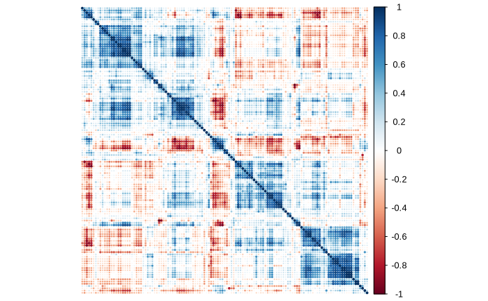

```r
corrplot(transCorr, order = "hclust", addgrid.col = NA, tl.pos = "n")
```

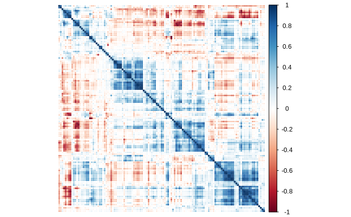

```r
ssData <- spatialSign(scale(filter1))
ssCorr <- cor(ssData)
corrplot(ssCorr, order = "hclust", addgrid.col = NA, tl.pos = "n")
```

This visualization indicates that correlations lessen with increasing levels of transformations:

```r
corrInfo <- function(x) summary(x[upper.tri(x)])
corrInfo(rawCorr)
```

```
    Min.  1st Qu.   Median     Mean  3rd Qu.     Max.
-1.00000 -0.16173  0.06434  0.07068  0.28643  1.00000
```

```r
corrInfo(transCorr)
```

```
    Min.  1st Qu.   Median     Mean  3rd Qu.     Max.
-0.98924 -0.16609  0.05929  0.06798  0.28774  1.00000
```

```r
corrInfo(ssCorr)
```

```
    Min.  1st Qu.   Median     Mean  3rd Qu.     Max.
-1.00000 -0.16062  0.03862  0.05561  0.25545  1.00000
```

| value | threshold | what |
| --- | --- | --- |
| 8.00000000 | 0.25 | Predictors |
| 9.00000000 | 0.30 | Predictors |
| 15.00000000 | 0.35 | Predictors |
| 18.00000000 | 0.40 | Predictors |
| 25.00000000 | 0.45 | Predictors |
| 30.00000000 | 0.50 | Predictors |
| 34.00000000 | 0.55 | Predictors |
| 43.00000000 | 0.60 | Predictors |
| 49.00000000 | 0.65 | Predictors |
| 53.00000000 | 0.70 | Predictors |

[output cut: 20 more lines]

```r
caret::findCorrelation(rawCorr, cutoff = 0.98, names = T)
```

```
 [1] "volume" "dpsa2"  "chdh1"  "scdh1"  "scdh3"  "tpsa"   "weight" "fpsa1"  "ppsa2"  "hbdnr"  "mchg"
```

We can also try the subselect package (Cerdeira, Silva, Cadima & Minhoto 2014) to remove predic- tors. This package uses a different criterion to evaluate the quality of a subset and has less greedy methods to search the predictor space. First, we have to remove all linear dependencies from the data. That includes perfect pair–wise correlations as well as relationships between three or more predictors. The trim.matrix function does that:

```r
library(subselect)
ncol(rawCorr)
```

```
[1] 127
```

```r
trimmed <- trim.matrix(rawCorr, tolval=1000*.Machine$double.eps)$trimmedmat
ncol(trimmed)
```

```
[1] 119
```

We can use simulated annealing and genetic algorithms to search for quality subsets. These techniques allow for lower and upper limits for the number of predictors. However, the functions get dramatically slower as the range increases. Here, we will look at one solution found by findCorrelation and, will subsequently use subselect to search within that subset size:

```r
corrInfo(fcMat)
```

```
     Min.   1st Qu.    Median      Mean   3rd Qu.      Max.
-0.254356 -0.097568  0.005174  0.012444  0.088337  0.380312
```

```r
corrInfo(saMat)
```

```
    Min.  1st Qu.   Median     Mean  3rd Qu.     Max.
-0.77854 -0.11441  0.06454  0.09295  0.29307  0.89491
```

```r
corrInfo(gaMat)
```

```
    Min.  1st Qu.   Median     Mean  3rd Qu.     Max.
-0.52584 -0.04971  0.12630  0.12990  0.28588  0.82354
```

The main difference between these results is that the greedy approach of **findCorrelation** is much more conservative than the techniques found in the subselect package.

## 4 Over-Fitting and Model Tuning

# Part II Regression Models

## 5 Measuring Performance in Regression Models

## 6 Linear Regression and Its Cousins

## 7 Nonlinear Regression Models

## 8 Regression Trees and Rule-Based Models

## 9 A Summary of Solubility Models

## 10 Case Study: Compressive Strength of Concrete Mixtures

# Part III Classification Models

## 11 Measuring Performance in Classification Models

## 12 Discriminant Analysis and Other Linear Classification Models

## 13 Nonlinear Classification Models

## 14 Classification Trees and Rule-Based Models

## 15 A Summary of Grant Application Models

## 16 Remedies for Severe Class Imbalance

## 17 Case Study: Job Scheduling

# Part IV Other Considerations

## 18 Measuring Predictor Importance

## 19 An Introduction to Feature Selection

## 20 Factors That Can Affect Model Performance